# Web Scraping

Biostat 203B

Dr. Hua Zhou @ UCLA

Feb 1, 2022

Load tidyverse and other packages for this lecture:

## Web scraping

There is a wealth of data on internet. How to scrape them and analyze them?

## rvest

rvest is an R package written by Hadley Wickham which makes web scraping easy.

## Example: Scraping from webpage

- We follow instructions in a [Blog by SAURAV KAUSHIK](https://www.analyticsvidhya.com/blog/2017/03/beginners-guide-on-web-scraping-in-r-using-rvest-with-hands-on-knowledge/) to find the most popular feature films of 2020.
- Install the [SelectorGadget](https://selectorgadget.com/) extension for Chrome.
- The 100 most popular feature films released in 2020 can be accessed at page https://www.imdb.com/search/title/?title_type=feature&release_date=2020-01-01,2020-12-31&count=100.

  ```r
  #Loading the rvest and tidyverse package
  #Specifying the url for desired website to be scraped
  url <- "https://www.imdb.com/search/title/?title_type=feature&release_date=2020-01-01,2020-12-31&count=100"
  #Reading the HTML code from the website
  (webpage <- read_html(url))
  ```

  ```
  ## {html_document}
  ## <html xmlns:og="http://ogp.me/ns#" xmlns:fb="http://www.facebook.com/2008/fbml">
  ## [1] <head>\n<meta http-equiv="Content-Type" content="text/html; charset=UTF-8 ...
  ## [2] <body id="styleguide-v2" class="fixed">\n            <img height="1" widt ...
  ```

- Suppose we want to scrape following 11 features from this page:
  - Rank
  - Title
  - Description
  - Runtime
  - Genre
  - Rating
  - Metascore
  - Votes
  - Gross_Eerning_in_Mil
  - Director
  - Actor

[figure not shown]

### Rank

- Use SelectorGadget to highlight the element we want to scrape

[figure not shown]

- Use the CSS selector to get the rankings

  ```r
  # Use CSS selectors to scrap the rankings section
  (rank_data_html <- html_nodes(webpage, '.text-primary'))
  ```

  ```
  ## {xml_nodeset (100)}
  ##  [1] <span class="lister-item-index unbold text-primary">1.</span>
  ##  [2] <span class="lister-item-index unbold text-primary">2.</span>
  ##  [3] <span class="lister-item-index unbold text-primary">3.</span>
  ##  [4] <span class="lister-item-index unbold text-primary">4.</span>
  ##  [5] <span class="lister-item-index unbold text-primary">5.</span>
  ##  [6] <span class="lister-item-index unbold text-primary">6.</span>
  ##  [7] <span class="lister-item-index unbold text-primary">7.</span>
  ##  [8] <span class="lister-item-index unbold text-primary">8.</span>
  ##  [9] <span class="lister-item-index unbold text-primary">9.</span>
  ## [10] <span class="lister-item-index unbold text-primary">10.</span>
  ## [11] <span class="lister-item-index unbold text-primary">11.</span>
  ## [12] <span class="lister-item-index unbold text-primary">12.</span>
  ## [13] <span class="lister-item-index unbold text-primary">13.</span>
  ## [14] <span class="lister-item-index unbold text-primary">14.</span>
  ## [15] <span class="lister-item-index unbold text-primary">15.</span>
  ## [16] <span class="lister-item-index unbold text-primary">16.</span>
  ## [17] <span class="lister-item-index unbold text-primary">17.</span>
  ## [18] <span class="lister-item-index unbold text-primary">18.</span>
  ## [19] <span class="lister-item-index unbold text-primary">19.</span>
  ## [20] <span class="lister-item-index unbold text-primary">20.</span>
  ## ...
  ```

  ```r
  # Convert the ranking data to text
  (rank_data <- html_text(rank_data_html))
  ```

  ```
  ##   [1] "1."   "2."   "3."   "4."   "5."   "6."   "7."   "8."   "9."   "10."
  ##  [11] "11."  "12."  "13."  "14."  "15."  "16."  "17."  "18."  "19."  "20."
  ##  [21] "21."  "22."  "23."  "24."  "25."  "26."  "27."  "28."  "29."  "30."
  ##  [31] "31."  "32."  "33."  "34."  "35."  "36."  "37."  "38."  "39."  "40."
  ##  [41] "41."  "42."  "43."  "44."  "45."  "46."  "47."  "48."  "49."  "50."
  ##  [51] "51."  "52."  "53."  "54."  "55."  "56."  "57."  "58."  "59."  "60."
  ##  [61] "61."  "62."  "63."  "64."  "65."  "66."  "67."  "68."  "69."  "70."
  ##  [71] "71."  "72."  "73."  "74."  "75."  "76."  "77."  "78."  "79."  "80."
  ##  [81] "81."  "82."  "83."  "84."  "85."  "86."  "87."  "88."  "89."  "90."
  ##  [91] "91."  "92."  "93."  "94."  "95."  "96."  "97."  "98."  "99."  "100."
  ```

  ```r
  # Turn into numerical values
  (rank_data <- as.integer(rank_data))
  ```

  ```
  ##   [1]   1   2   3   4   5   6   7   8   9  10  11  12  13  14  15  16  17  18
  ##  [19]  19  20  21  22  23  24  25  26  27  28  29  30  31  32  33  34  35  36
  ##  [37]  37  38  39  40  41  42  43  44  45  46  47  48  49  50  51  52  53  54
  ##  [55]  55  56  57  58  59  60  61  62  63  64  65  66  67  68  69  70  71  72
  ##  [73]  73  74  75  76  77  78  79  80  81  82  83  84  85  86  87  88  89  90
  ##  [91]  91  92  93  94  95  96  97  98  99 100
  ```

### Title

- Use SelectorGadget to find the CSS selector `.lister-item-header a`.

  ```r
  # Using CSS selectors to scrap the title section
  (title_data_html <- html_nodes(webpage, '.lister-item-header a'))
  ```

  ```
  ## {xml_nodeset (100)}
  ##  [1] <a href="/title/tt10023022/?ref_=adv_li_tt">Clean</a>
  ##  [2] <a href="/title/tt10886166/?ref_=adv_li_tt">365 Days</a>
  ##  [3] <a href="/title/tt10272386/?ref_=adv_li_tt">The Father</a>
  ##  [4] <a href="/title/tt6723592/?ref_=adv_li_tt">Tenet</a>
  ##  [5] <a href="/title/tt9620292/?ref_=adv_li_tt">Promising Young Woman</a>
  ##  [6] <a href="/title/tt9214832/?ref_=adv_li_tt">Emma.</a>
  ##  [7] <a href="/title/tt9731534/?ref_=adv_li_tt">The Night House</a>
  ##  [8] <a href="/title/tt8332922/?ref_=adv_li_tt">A Quiet Place Part II</a>
  ##  [9] <a href="/title/tt10362466/?ref_=adv_li_tt">After We Collided</a>
  ## [10] <a href="/title/tt10288566/?ref_=adv_li_tt">Another Round</a>
  ## [11] <a href="/title/tt7395114/?ref_=adv_li_tt">The Devil All the Time</a>
  ## [12] <a href="/title/tt8503618/?ref_=adv_li_tt">Hamilton</a>
  ## [13] <a href="/title/tt6673612/?ref_=adv_li_tt">Dolittle</a>
  ## [14] <a href="/title/tt9770150/?ref_=adv_li_tt">Nomadland</a>
  ## [15] <a href="/title/tt8368512/?ref_=adv_li_tt">The Courier</a>
  ## [16] <a href="/title/tt7126948/?ref_=adv_li_tt">Wonder Woman 1984</a>
  ## [17] <a href="/title/tt6475714/?ref_=adv_li_tt">Monster Hunter</a>
  ## [18] <a href="/title/tt2948372/?ref_=adv_li_tt">Soul</a>
  ## [19] <a href="/title/tt11655202/?ref_=adv_li_tt">Riders of Justice</a>
  ## [20] <a href="/title/tt9893250/?ref_=adv_li_tt">I Care a Lot</a>
  ## ...
  ```

  ```r
  # Converting the title data to text
  (title_data <- html_text(title_data_html))
  ```

  ```
  ##   [1] "Clean"
  ##   [2] "365 Days"
  ##   [3] "The Father"
  ##   [4] "Tenet"
  ##   [5] "Promising Young Woman"
  ##   [6] "Emma."
  ##   [7] "The Night House"
  ##   [8] "A Quiet Place Part II"
  ##   [9] "After We Collided"
  ##  [10] "Another Round"
  ##  [11] "The Devil All the Time"
  ##  [12] "Hamilton"
  ##  [13] "Dolittle"
  ##  [14] "Nomadland"
  ##  [15] "The Courier"
  ```

  [output cut: 85 more lines]

### Description

- ```r
  # Using CSS selectors to scrap the description section
  (description_data_html <- html_nodes(webpage, '.ratings-bar+ .text-muted'))
  ```

  ```
  ## {xml_nodeset (100)}
  ##  [1] <p class="text-muted">\nTormented by his past, a garbage man named Clean ...
  ##  [2] <p class="text-muted">\nMassimo is a member of the Sicilian Mafia family ...
  ##  [3] <p class="text-muted">\nA man refuses all assistance from his daughter a ...
  ##  [4] <p class="text-muted">\nArmed with only one word, Tenet, and fighting fo ...
  ##  [5] <p class="text-muted">\nA young woman, traumatized by a tragic event in  ...
  ##  [6] <p class="text-muted">\nIn 1800s England, a well meaning but selfish you ...
  ##  [7] <p class="text-muted">\nA widow begins to uncover her recently deceased  ...
  ##  [8] <p class="text-muted">\nFollowing the events at home, the Abbott family  ...
  ##  [9] <p class="text-muted">\nBased on the 2014 romance novel of the same name ...
  ## [10] <p class="text-muted">\nFour high school teachers consume alcohol on a d ...
  ## [11] <p class="text-muted">\nSinister characters converge around a young man  ...
  ## [12] <p class="text-muted">\nThe real life of one of America's foremost found ...
  ## [13] <p class="text-muted">\nA physician who can talk to animals embarks on a ...
  ## [14] <p class="text-muted">\nA woman in her sixties, after losing everything  ...
  ## [15] <p class="text-muted">\nCold War spy Greville Wynne and his Russian sour ...
  ## [16] <p class="text-muted">\nDiana must contend with a work colleague and bus ...
  ## [17] <p class="text-muted">\nWhen Cpt. Artemis and her loyal soldiers are tra ...
  ## [18] <p class="text-muted">\nAfter landing the gig of a lifetime, a New York  ...
  ## [19] <p class="text-muted">\nMarkus goes home to his teenage daughter, Mathil ...
  ## [20] <p class="text-muted">\nA crooked legal guardian who drains the savings  ...
  ## ...
  ```

  ```r
  # Converting the description data to text
  description_data <- html_text(description_data_html)
  # take a look at first few
  head(description_data)
  ```

  ```
  ## [1] "\nTormented by his past, a garbage man named Clean attempts a quiet life of redemption. But, soon finds himself forced to reconcile with the violence of his past."
  ## [2] "\nMassimo is a member of the Sicilian Mafia family and Laura is a sales director. She does not expect that on a trip to Sicily trying to save her relationship, Massimo will kidnap her and give her 365 days to fall in love with him."
  ## [3] "\nA man refuses all assistance from his daughter as he ages. As he tries to make sense of his changing circumstances, he begins to doubt his loved ones, his own mind and even the fabric of his reality."
  ## [4] "\nArmed with only one word, Tenet, and fighting for the survival of the entire world, a Protagonist journeys through a twilight world of international espionage on a mission that will unfold in something beyond real time."
  ## [5] "\nA young woman, traumatized by a tragic event in her past, seeks out vengeance against those who crossed her path."
  ## [6] "\nIn 1800s England, a well meaning but selfish young woman meddles in the love lives of her friends."
  ```

  ```r
  # strip the '\n'
  description_data <- str_replace(description_data, "^\\n", "")
  head(description_data)
  ```

  ```
  ## [1] "Tormented by his past, a garbage man named Clean attempts a quiet life of redemption. But, soon finds himself forced to reconcile with the violence of his past."
  ## [2] "Massimo is a member of the Sicilian Mafia family and Laura is a sales director. She does not expect that on a trip to Sicily trying to save her relationship, Massimo will kidnap her and give her 365 days to fall in love with him."
  ## [3] "A man refuses all assistance from his daughter as he ages. As he tries to make sense of his changing circumstances, he begins to doubt his loved ones, his own mind and even the fabric of his reality."
  ## [4] "Armed with only one word, Tenet, and fighting for the survival of the entire world, a Protagonist journeys through a twilight world of international espionage on a mission that will unfold in something beyond real time."
  ## [5] "A young woman, traumatized by a tragic event in her past, seeks out vengeance against those who crossed her path."
  ## [6] "In 1800s England, a well meaning but selfish young woman meddles in the love lives of her friends."
  ```

### Runtime

- Retrieve runtime data

```r
# Using CSS selectors to scrap the Movie runtime section
(runtime_data <- webpage %>%
  html_nodes('.runtime') %>%
  html_text() %>%
  str_replace(" min", "") %>%
  as.integer())
```

```
##   [1]  94 114  97 150 113 124 107  97 105 117 138 160 101 107 112 151 103 100
##  [19] 116 118  94 109 117  90 124  90 109  95 136 123 124  88 100  99 117 115
##  [37] 129 137 107  90  91 125 109 134  83 106  90 116 119  86 123 115  94  90
##  [55] 109  95 124 105  96 106  77  95 104 118 123 102 131  94 102 129  91 111
##  [73] 101 100 126  89 100 118  90 120  99 119 116  88 104  99 115 122 109  90
##  [91] 103 107 104 113  91 113 108  98 127 111
```

### Genre

- Collect the (first) genre of each movie:

  ```r
  genre_data <- webpage %>%
    # Using CSS selectors to scrap the Movie genre section
    html_nodes('.genre') %>%
    # Converting the genre data to text
    html_text() %>%
    # Data-Preprocessing: retrieve the first word
    str_extract("[:alpha:]+")
  genre_data
  ```

  ```
  ##   [1] "Crime"     "Drama"     "Drama"     "Action"    "Crime"     "Comedy"
  ##   [7] "Horror"    "Drama"     "Drama"     "Comedy"    "Crime"     "Biography"
  ##  [13] "Adventure" "Drama"     "Drama"     "Action"    "Action"    "Animation"
  ##  [19] "Action"    "Comedy"    "Comedy"    "Action"    "Crime"     "Action"
  ##  [25] "Drama"     "Comedy"    "Action"    "Adventure" "Comedy"    "Action"
  ##  [31] "Drama"     "Comedy"    "Mystery"   "Action"    "Animation" "Action"
  ##  [37] "Drama"     "Horror"    "Drama"     "Action"    "Action"    "Action"
  ##  [43] "Action"    "Drama"     "Action"    "Thriller"  "Mystery"   "Action"
  ##  [49] "Action"    "Comedy"    "Drama"     "Drama"     "Action"    "Crime"
  ##  [55] "Crime"     "Animation" "Action"    "Drama"     "Thriller"  "Adventure"
  ##  [61] "Comedy"    "Drama"     "Comedy"    "Action"    "Comedy"    "Animation"
  ##  [67] "Biography" "Biography" "Comedy"    "Drama"     "Adventure" "Action"
  ##  [73] "Comedy"    "Horror"    "Drama"     "Adventure" "Adventure" "Adventure"
  ##  [79] "Comedy"    "Biography" "Horror"    "Drama"     "Drama"     "Comedy"
  ##  [85] "Comedy"    "Action"    "Drama"     "Animation" "Action"    "Animation"
  ##  [91] "Horror"    "Drama"     "Comedy"    "Crime"     "Comedy"    "Action"
  ##  [97] "Action"    "Action"    "Drama"     "Drama"
  ```

### Rating

- Rating data:

  ```r
  rating_data <- webpage %>%
    html_nodes('.ratings-imdb-rating strong') %>%
    html_text() %>%
    as.numeric()
  rating_data
  ```

  ```
  ##   [1] 5.7 3.3 8.3 7.4 7.5 6.7 6.5 7.3 5.2 7.7 7.1 8.4 5.6 7.3 7.2 5.4 5.3 8.1
  ##  [19] 7.6 6.3 5.0 4.9 6.9 6.5 7.1 7.4 6.1 5.9 7.1 6.6 7.1 6.2 6.8 6.5 8.2 5.7
  ##  [37] 7.8 6.2 6.3 6.0 7.0 6.7 7.0 6.6 4.9 6.8 6.7 6.7 6.4 6.5 6.0 7.5 5.3 5.2
  ##  [55] 6.4 7.0 6.5 6.2 5.4 5.3 7.2 6.9 6.6 6.8 6.5 7.4 6.9 5.8 6.4 6.2 6.0 6.2
  ##  [73] 5.8 6.2 7.1 5.5 6.8 5.6 5.7 6.5 4.8 6.3 6.1 4.8 6.3 6.0 7.6 8.6 5.7 6.1
  ##  [91] 6.5 6.5 5.7 6.7 5.5 6.0 6.4 6.3 7.4 5.6
  ```

### Votes

- Vote data

  ```r
  votes_data <- webpage %>%
    html_nodes('.sort-num_votes-visible span:nth-child(2)') %>%
    html_text() %>%
    str_replace(",", "") %>%
    as.numeric()
  votes_data
  ```

  ```
  ##   [1]   1719  72490 122060 450511 150403  45946  33609 194104  27974 131815
  ##  [11] 120985  81952  59472 143720  47005 246748  52801 297148  39183 123605
  ##  [21]   2820  46377  20255  96960 206854 142969 221078  76432  57626 156645
  ##  [31]  23522   5699  58849 113997  45887 141139 166635  23282  12473  61865
  ##  [41]  89424 152826 116353  78392  23790  33104  64348 187189 106744  10932
  ##  [51]  39186  70074  71524    244  21227  38036 151720   6762  51340  36581
  ##  [61]  16213   9661   9962  81579  89334 134889  69690   4921  49987  12778
  ##  [71]  43202  83009  35712  13231  46479   2031  46106  80331  37476  15618
  ##  [81]   3391   3385   3402    271   1429  46547  15964   7834  73903  21518
  ##  [91]  30962  27974   6624  23096    113  82853   3756  35231   6591  11994
  ```

### Director

- Director information

  ```r
  directors_data <- webpage %>%
    html_nodes('.text-muted+ p a:nth-child(1)') %>%
    html_text()
  directors_data
  ```

  ```
  ##   [1] "Paul Solet"                  "Barbara Bialowas"
  ##   [3] "Florian Zeller"              "Christopher Nolan"
  ##   [5] "Emerald Fennell"             "Autumn de Wilde"
  ##   [7] "David Bruckner"              "John Krasinski"
  ##   [9] "Roger Kumble"                "Thomas Vinterberg"
  ##  [11] "Antonio Campos"              "Thomas Kail"
  ##  [13] "Stephen Gaghan"              "Chloé Zhao"
  ##  [15] "Dominic Cooke"               "Patty Jenkins"
  ##  [17] "Paul W.S. Anderson"          "Pete Docter"
  ##  [19] "Anders Thomas Jensen"        "J Blakeson"
  ##  [21] "Gia Coppola"                 "Jeff Wadlow"
  ##  [23] "Robert Connolly"             "Craig Zobel"
  ##  [25] "Leigh Whannell"              "Max Barbakow"
  ##  [27] "Cathy Yan"                   "William Eubank"
  ##  [29] "Judd Apatow"                 "Harry Bradbeer"
  ```

  [output cut: 35 more lines]

### Actor

- Only the first actor

  ```r
  actors_data <- webpage %>%
    html_nodes('.lister-item-content .ghost+ a') %>%
    html_text()
  actors_data
  ```

  ```
  ##   [1] "Adrien Brody"           "Anna Maria Sieklucka"   "Anthony Hopkins"
  ##   [4] "John David Washington"  "Carey Mulligan"         "Anya Taylor-Joy"
  ##   [7] "Rebecca Hall"           "Emily Blunt"            "Josephine Langford"
  ##  [10] "Mads Mikkelsen"         "Bill Skarsgård"         "Lin-Manuel Miranda"
  ##  [13] "Robert Downey Jr."      "Frances McDormand"      "Benedict Cumberbatch"
  ##  [16] "Gal Gadot"              "Milla Jovovich"         "Jamie Foxx"
  ##  [19] "Mads Mikkelsen"         "Rosamund Pike"          "Andrew Garfield"
  ##  [22] "Michael Peña"           "Eric Bana"              "Betty Gilpin"
  ##  [25] "Elisabeth Moss"         "Andy Samberg"           "Margot Robbie"
  ##  [28] "Kristen Stewart"        "Pete Davidson"          "Millie Bobby Brown"
  ##  [31] "Gijs Blom"              "Wallace Shawn"          "Frank Grillo"
  ##  [34] "Ben Schwartz"           "Natsuki Hanae"          "Liu Yifei"
  ##  [37] "Eddie Redmayne"         "James Badge Dale"       "Jude Law"
  ##  [40] "Russell Crowe"          "Tom Hanks"              "Charlize Theron"
  ##  [43] "Dylan O'Brien"          "Jesse Plemons"          "Chloë Grace Moretz"
  ```

  [output cut: 19 more lines]

### Metascore

- We encounter the issue of missing data when scraping metascore.
- We see there are only 90 meta scores. 10 movies don’t have meta scores. We may manually find which movies don’t have meta scores but that’s tedious and not reproducible.

  ```r
  # Using CSS selectors to scrap the metascore section
  ms_data_html <- html_nodes(webpage, '.metascore')
  # Converting the runtime data to text
  ms_data <- html_text(ms_data_html)
  # Let's have a look at the metascore
  ms_data <- str_replace(ms_data, "\\s*$", "") %>% as.integer()
  ms_data
  ```

  ```
  ##  [1] 43 88 69 73 71 68 71 14 79 55 90 26 93 65 60 47 83 81 66 36 22 69 50 72 83
  ## [26] 60 48 67 68 43 56 47 75 66 76 80 40 64 70 63 78 66 56 67 56 64 76 46 89 43
  ## [51] 13 56 59 73 39 47 79 73 79 73 50 61 79 54 67 52 65 49 22 62 66 48 58 33 72
  ## [76] 62 41 58 51 46 51 44 51 72 61 63 71 51 67 31
  ```

- First let’s tally index and corresponding metascore (if present).

  ```r
  rank_and_metascore <- webpage %>%
    html_nodes('.unfavorable , .text-primary , .favorable , .mixed') %>%
    html_text() %>%
    str_replace("\\s*$", "") %>%
    print()
  ```

  ```
  ##   [1] "1."   "43"   "2."   "3."   "88"   "4."   "69"   "5."   "73"   "6."
  ##  [11] "71"   "7."   "68"   "8."   "71"   "9."   "14"   "10."  "79"   "11."
  ##  [21] "55"   "12."  "90"   "13."  "26"   "14."  "93"   "15."  "65"   "16."
  ##  [31] "60"   "17."  "47"   "18."  "83"   "19."  "81"   "20."  "66"   "21."
  ##  [41] "36"   "22."  "22"   "23."  "69"   "24."  "50"   "25."  "72"   "26."
  ##  [51] "83"   "27."  "60"   "28."  "48"   "29."  "67"   "30."  "68"   "31."
  ##  [61] "32."  "43"   "33."  "56"   "34."  "47"   "35."  "75"   "36."  "66"
  ##  [71] "37."  "76"   "38."  "39."  "80"   "40."  "40"   "41."  "64"   "42."
  ##  [81] "70"   "43."  "63"   "44."  "78"   "45."  "66"   "46."  "56"   "47."
  ##  [91] "67"   "48."  "56"   "49."  "64"   "50."  "76"   "51."  "46"   "52."
  ## [101] "89"   "53."  "43"   "54."  "55."  "13"   "56."  "56"   "57."  "59"
  ## [111] "58."  "73"   "59."  "39"   "60."  "47"   "61."  "79"   "62."  "73"
  ## [121] "63."  "79"   "64."  "73"   "65."  "50"   "66."  "61"   "67."  "79"
  ## [131] "68."  "54"   "69."  "67"   "70."  "52"   "71."  "65"   "72."  "49"
  ## [141] "73."  "22"   "74."  "62"   "75."  "66"   "76."  "77."  "48"   "78."
  ## [151] "58"   "79."  "33"   "80."  "72"   "81."  "62"   "82."  "41"   "83."
  ## [161] "58"   "84."  "85."  "51"   "86."  "46"   "87."  "51"   "88."  "89."
  ## [171] "44"   "90."  "51"   "91."  "72"   "92."  "61"   "93."  "94."  "63"
  ## [181] "95."  "71"   "96."  "51"   "97."  "67"   "98."  "99."  "100." "31"
  ```

  ```r
  isrank <- str_detect(rank_and_metascore, "\\.$")
  ismissing <- isrank[1:(length(rank_and_metascore) - 1)] & isrank[2:(length(rank_and_metascore))]
  ismissing[length(ismissing) + 1] <- isrank[length(isrank)]
  missingpos <- as.integer(rank_and_metascore[ismissing])
  metascore_data <- rep(NA, 100)
  metascore_data[-missingpos] <- ms_data
  metascore_data
  ```

  ```
  ##   [1] 43 NA 88 69 73 71 68 71 14 79 55 90 26 93 65 60 47 83 81 66 36 22 69 50 72
  ##  [26] 83 60 48 67 68 NA 43 56 47 75 66 76 NA 80 40 64 70 63 78 66 56 67 56 64 76
  ##  [51] 46 89 43 NA 13 56 59 73 39 47 79 73 79 73 50 61 79 54 67 52 65 49 22 62 66
  ##  [76] NA 48 58 33 72 62 41 58 NA 51 46 51 NA 44 51 72 61 NA 63 71 51 67 NA NA 31
  ```

### Gross

- Be careful with missing data.

  ```r
  # Using CSS selectors to scrap the gross revenue section
  gross_data_html <- html_nodes(webpage,'.ghost~ .text-muted+ span')
  # Converting the gross revenue data to text
  gross_data <- html_text(gross_data_html)
  # Let's have a look at the gross data
  gross_data
  ```

  ```
  ##  [1] "$58.46M"  "$160.07M" "$2.39M"   "$77.05M"  "$46.37M"  "$27.31M"
  ##  [7] "$70.41M"  "$84.16M"  "$148.97M" "$47.70M"  "$1.07M"   "$58.57M"
  ## [13] "$206.31M" "$61.56M"  "$62.34M"
  ```

  ```r
  # Data-Preprocessing: removing '$' and 'M' signs
  gross_data <- str_replace(gross_data, "M", "")
  gross_data <- str_sub(gross_data, 2, 10)
  #(gross_data <- str_extract(gross_data, "[:digit:]+.[:digit:]+"))
  gross_data <- as.numeric(gross_data)
  # Let's check the length of gross data
  gross_data
  ```

  ```
  ##  [1]  58.46 160.07   2.39  77.05  46.37  27.31  70.41  84.16 148.97  47.70
  ## [11]   1.07  58.57 206.31  61.56  62.34
  ```

  85 (out of 100) movies don’t have gross data yet! We need a better way to figure out missing entries.

  ```r
  (rank_and_gross <- webpage %>%
    # retrieve rank and gross
    html_nodes('.ghost~ .text-muted+ span , .text-primary') %>%
    html_text() %>%
    str_replace("\\s+", "") %>%
    str_replace_all("[$M]", ""))
  ```

  ```
  ##   [1] "1."     "2."     "3."     "4."     "58.46"  "5."     "6."     "7."
  ##   [9] "8."     "160.07" "9."     "2.39"   "10."    "11."    "12."    "13."
  ##  [17] "77.05"  "14."    "15."    "16."    "46.37"  "17."    "18."    "19."
  ##  [25] "20."    "21."    "22."    "27.31"  "23."    "24."    "25."    "70.41"
  ##  [33] "26."    "27."    "84.16"  "28."    "29."    "30."    "31."    "32."
  ##  [41] "33."    "34."    "148.97" "35."    "47.70"  "36."    "37."    "38."
  ##  [49] "39."    "40."    "41."    "42."    "43."    "1.07"   "44."    "45."
  ##  [57] "46."    "47."    "48."    "49."    "50."    "51."    "52."    "53."
  ##  [65] "54."    "55."    "56."    "58.57"  "57."    "206.31" "58."    "59."
  ##  [73] "60."    "61."    "62."    "63."    "64."    "65."    "66."    "61.56"
  ##  [81] "67."    "68."    "69."    "70."    "71."    "72."    "73."    "74."
  ##  [89] "75."    "76."    "77."    "62.34"  "78."    "79."    "80."    "81."
  ##  [97] "82."    "83."    "84."    "85."    "86."    "87."    "88."    "89."
  ## [105] "90."    "91."    "92."    "93."    "94."    "95."    "96."    "97."
  ## [113] "98."    "99."    "100."
  ```

  ```r
  isrank <- str_detect(rank_and_gross, "\\.$")
  ismissing <- isrank[1:(length(rank_and_gross) - 1)] & isrank[2:(length(rank_and_gross))]
  ismissing[length(ismissing)+1] <- isrank[length(isrank)]
  missingpos <- as.integer(rank_and_gross[ismissing])
  gs_data <- rep(NA, 100)
  gs_data[-missingpos] <- gross_data
  (gross_data <- gs_data)
  ```

  ```
  ##   [1]     NA     NA     NA  58.46     NA     NA     NA 160.07   2.39     NA
  ##  [11]     NA     NA  77.05     NA     NA  46.37     NA     NA     NA     NA
  ##  [21]     NA  27.31     NA     NA  70.41     NA  84.16     NA     NA     NA
  ##  [31]     NA     NA     NA 148.97  47.70     NA     NA     NA     NA     NA
  ##  [41]     NA     NA   1.07     NA     NA     NA     NA     NA     NA     NA
  ##  [51]     NA     NA     NA     NA     NA  58.57 206.31     NA     NA     NA
  ##  [61]     NA     NA     NA     NA     NA  61.56     NA     NA     NA     NA
  ##  [71]     NA     NA     NA     NA     NA     NA  62.34     NA     NA     NA
  ##  [81]     NA     NA     NA     NA     NA     NA     NA     NA     NA     NA
  ##  [91]     NA     NA     NA     NA     NA     NA     NA     NA     NA     NA
  ```

### Visualizing movie data

- Form a tibble:

  ```r
  # Combining all the lists to form a data frame
  movies <- tibble(Rank = rank_data,
                   Title = title_data,
                   Description = description_data,
                   Runtime = runtime_data,
                   Genre = genre_data,
                   Rating = rating_data,
                   Metascore = metascore_data,
                   Votes = votes_data,
                   Gross_Earning_in_Mil = gross_data,
                   Director = directors_data,
                   Actor = actors_data)
  movies %>% print(width=Inf)
  ```

  ```
  ## # A tibble: 100 × 11
  ##     Rank Title
  ##    <int> <chr>
  ##  1     1 Clean
  ##  2     2 365 Days
  ##  3     3 The Father
  ##  4     4 Tenet
  ##  5     5 Promising Young Woman
  ##  6     6 Emma.
  ##  7     7 The Night House
  ##  8     8 A Quiet Place Part II
  ##  9     9 After We Collided
  ## 10    10 Another Round
  ##    Description
  ##    <chr>
  ```

  [output cut: 35 more lines]

- How many top 100 movies are in each genre? (Be careful with interpretation.)

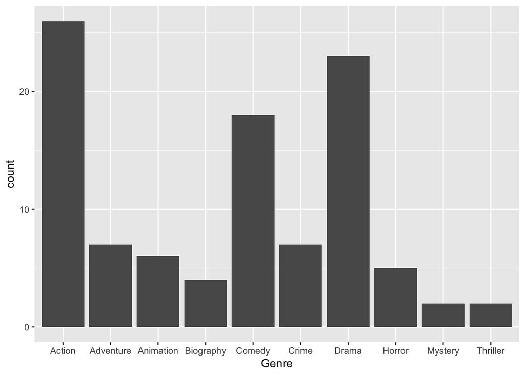

  ```r
  movies %>%
    ggplot() +
    geom_bar(mapping = aes(x = Genre))
  ```

- Which genre is most profitable in terms of average gross earnings?

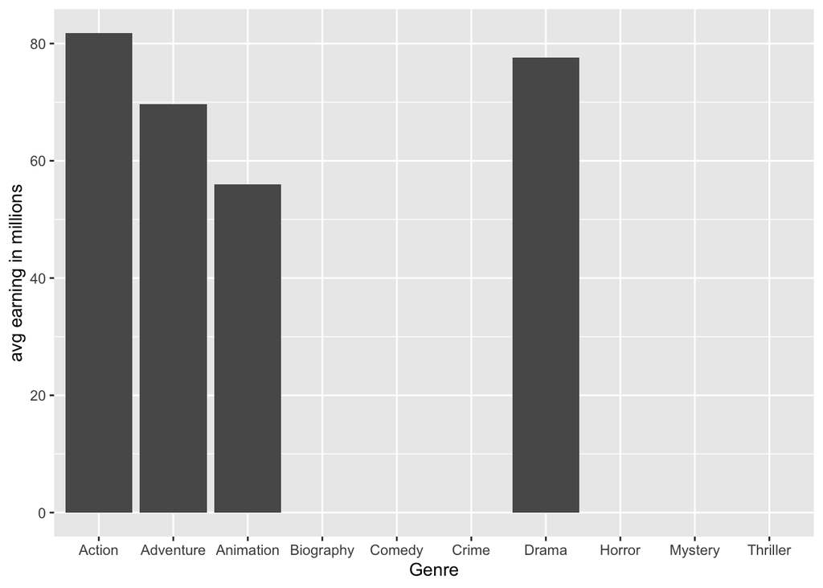

  ```r
  movies %>%
    group_by(Genre) %>%
    summarise(avg_earning = mean(Gross_Earning_in_Mil, na.rm = TRUE)) %>%
    ggplot() +
      geom_col(mapping = aes(x = Genre, y = avg_earning)) +
      labs(y = "avg earning in millions")
  ```

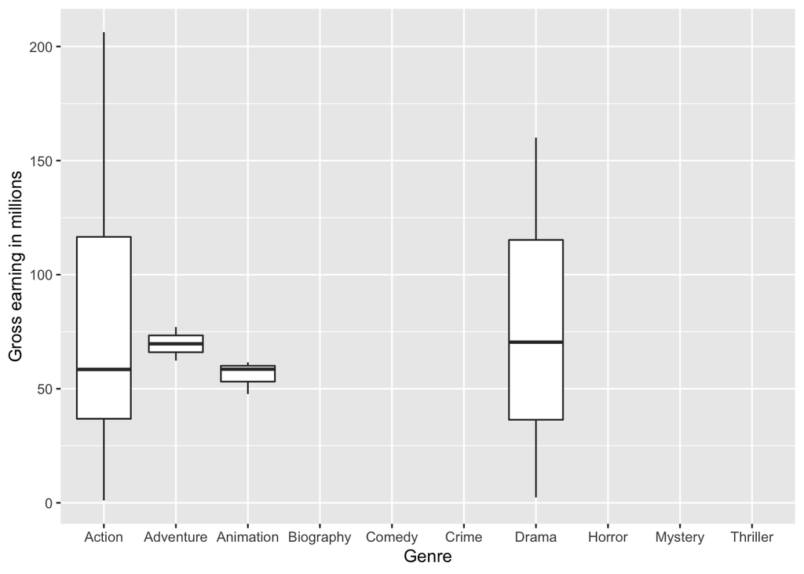

  ```r
  ggplot(data = movies) +
    geom_boxplot(mapping = aes(x = Genre, y = Gross_Earning_in_Mil)) +
    labs(y = "Gross earning in millions")
  ```

- Is there a relationship between gross earning and rating? Find the best selling movie (by gross earning) in each genre

  ```r
  library("ggrepel")
  (best_in_genre <- movies %>%
      group_by(Genre) %>%
      filter(row_number(desc(Gross_Earning_in_Mil)) == 1)) %>%
      print(width = Inf)
  ```

  ```
  ## # A tibble: 4 × 11
  ## # Groups:   Genre [4]
  ##    Rank Title
  ##   <int> <chr>
  ## 1     8 A Quiet Place Part II
  ## 2    13 Dolittle
  ## 3    57 Bad Boys for Life
  ## 4    66 Onward
  ##   Description
  ##   <chr>
  ## 1 Following the events at home, the Abbott family now face the terrors of the o…
  ## 2 A physician who can talk to animals embarks on an adventure to find a legenda…
  ## 3 Miami detectives Mike Lowrey and Marcus Burnett must face off against a mothe…
  ## 4 Two elven brothers embark on a quest to bring their father back for one day.
  ##   Runtime Genre     Rating Metascore  Votes Gross_Earning_in_Mil Director
  ##     <int> <chr>      <dbl>     <int>  <dbl>                <dbl> <chr>
  ## 1      97 Drama        7.3        71 194104                160.  John Krasinski
  ## 2     101 Adventure    5.6        26  59472                 77.0 Stephen Gaghan
  ## 3     124 Action       6.5        59 151720                206.  Adil El Arbi
  ## 4     102 Animation    7.4        61 134889                 61.6 Dan Scanlon
  ##   Actor
  ##   <chr>
  ## 1 Emily Blunt
  ## 2 Robert Downey Jr.
  ## 3 Will Smith
  ## 4 Tom Holland
  ```

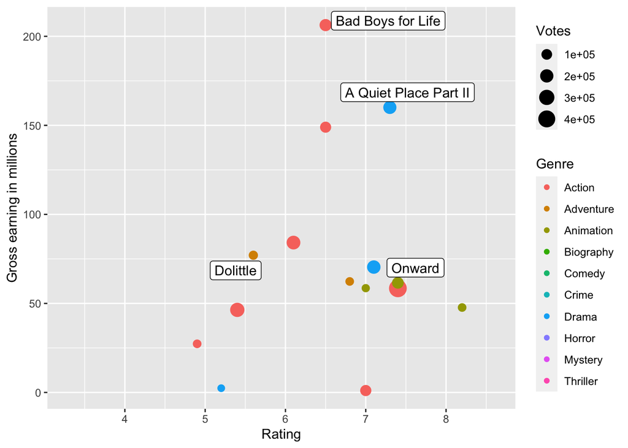

  ```r
  ggplot(movies, mapping = aes(x = Rating, y = Gross_Earning_in_Mil)) +
    geom_point(mapping = aes(size = Votes, color = Genre)) +
    ggrepel::geom_label_repel(aes(label = Title), data = best_in_genre) +
    labs(y = "Gross earning in millions")
  ```

## Example: Scraping finance data

- `quantmod` package contains many utility functions for retrieving and plotting finance data. E.g.,

  ```r
  library(quantmod)
  stock <- getSymbols("TSLA", src = "yahoo", auto.assign = FALSE, from = "2020-01-01")
  ```

  ```r
  head(stock)
  ```

  ```
  ##            TSLA.Open TSLA.High TSLA.Low TSLA.Close TSLA.Volume TSLA.Adjusted
  ## 2020-01-02    84.900    86.140   84.342     86.052    47660500        86.052
  ## 2020-01-03    88.100    90.800   87.384     88.602    88892500        88.602
  ## 2020-01-06    88.094    90.312   88.000     90.308    50665000        90.308
  ## 2020-01-07    92.280    94.326   90.672     93.812    89410500        93.812
  ## 2020-01-08    94.740    99.698   93.646     98.428   155721500        98.428
  ## 2020-01-09    99.420    99.760   94.574     96.268   142202000        96.268
  ```

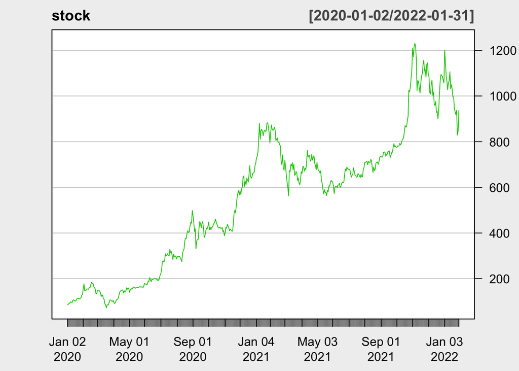

  ```r
  chartSeries(stock, theme = chartTheme("white"),
              type = "line", log.scale = FALSE, TA = NULL)
  ```

## Example: Pull tweets into R

- Read blog: https://towardsdatascience.com/pulling-tweets-into-r-e17d4981cfe2
- [`twitteR` package](https://www.rdocumentation.org/packages/twitteR) is useful for pulling tweets text data into R.

```r
library(twitteR) #load package
```

- Step 1: apply for a [Twitter developer account](https://developer.twitter.com). It takes some time to get approved.
- Step 2: Generate and copy the Twitter App Keys.

```
consumer_key <- 'XXXXXXXXXX'
consumer_secret <- 'XXXXXXXXXX'
access_token <- 'XXXXXXXXXX'
access_secret <- 'XXXXXXXXXX'
```

- Step 3. Set up authentication

```r
setup_twitter_oauth(consumer_key, consumer_secret, access_token, access_secret)
```

- Step 4: Pull tweets

```r
virus <- searchTwitter('#China + #Coronavirus',
                       n = 1000,
                       since = '2020-01-01',
                       retryOnRateLimit = 1e3)
virus_df <- as_tibble(twListToDF(virus))
virus_df %>% print(width = Inf)
```